# Risk Factor Analysis

## Outcome Variable

**Outcome Variable:** wast_rec90d

## Predictor Variables

**Intervention Variable:** cleanck

**Adjustment Set:**

- arm
- sex
- W_mage
- meducyrs
- feducyrs
- hhwealth_quart
- W_nrooms
- impfloor
- delta_meducyrs
- delta_feducyrs
- delta_hhwealth_quart
- delta_W_nrooms
- delta_impfloor

## Stratifying Variables

The analysis was stratified on these variable(s):

- agecat
- studyid
- country

## Data Summary

| agecat | studyid | country | cleanck | wast_rec90d | n_cell | n |
| --- | --- | --- | --- | --- | --- | --- |
| 0-24 months | CMC-V-BCS-2002 | INDIA | 1 | 0 | 38 | 324 |
| 0-24 months | CMC-V-BCS-2002 | INDIA | 1 | 1 | 80 | 324 |
| 0-24 months | CMC-V-BCS-2002 | INDIA | 0 | 0 | 82 | 324 |
| 0-24 months | CMC-V-BCS-2002 | INDIA | 0 | 1 | 124 | 324 |
| 0-24 months | GMS-Nepal | NEPAL | 1 | 0 | 6 | 583 |
| 0-24 months | GMS-Nepal | NEPAL | 1 | 1 | 3 | 583 |
| 0-24 months | GMS-Nepal | NEPAL | 0 | 0 | 259 | 583 |
| 0-24 months | GMS-Nepal | NEPAL | 0 | 1 | 315 | 583 |
| 0-24 months | IRC | INDIA | 1 | 0 | 84 | 383 |
| 0-24 months | IRC | INDIA | 1 | 1 | 135 | 383 |
| 0-24 months | IRC | INDIA | 0 | 0 | 72 | 383 |
| 0-24 months | IRC | INDIA | 0 | 1 | 92 | 383 |
| 0-24 months | MAL-ED | SOUTH AFRICA | 1 | 0 | 0 | 1 |
| 0-24 months | MAL-ED | SOUTH AFRICA | 1 | 1 | 1 | 1 |
| 0-24 months | MAL-ED | SOUTH AFRICA | 0 | 0 | 0 | 1 |
| 0-24 months | MAL-ED | SOUTH AFRICA | 0 | 1 | 0 | 1 |
| 0-24 months | NIH-Crypto | BANGLADESH | 1 | 0 | 44 | 215 |
| 0-24 months | NIH-Crypto | BANGLADESH | 1 | 1 | 68 | 215 |
| 0-24 months | NIH-Crypto | BANGLADESH | 0 | 0 | 37 | 215 |
| 0-24 months | NIH-Crypto | BANGLADESH | 0 | 1 | 66 | 215 |
| 0-24 months | PROVIDE | BANGLADESH | 1 | 0 | 91 | 308 |
| 0-24 months | PROVIDE | BANGLADESH | 1 | 1 | 144 | 308 |
| 0-24 months | PROVIDE | BANGLADESH | 0 | 0 | 38 | 308 |
| 0-24 months | PROVIDE | BANGLADESH | 0 | 1 | 35 | 308 |
| 0-6 months | CMC-V-BCS-2002 | INDIA | 1 | 0 | 21 | 201 |
| 0-6 months | CMC-V-BCS-2002 | INDIA | 1 | 1 | 57 | 201 |
| 0-6 months | CMC-V-BCS-2002 | INDIA | 0 | 0 | 45 | 201 |
| 0-6 months | CMC-V-BCS-2002 | INDIA | 0 | 1 | 78 | 201 |
| 0-6 months | GMS-Nepal | NEPAL | 1 | 0 | 4 | 238 |
| 0-6 months | GMS-Nepal | NEPAL | 1 | 1 | 2 | 238 |
| 0-6 months | GMS-Nepal | NEPAL | 0 | 0 | 90 | 238 |
| 0-6 months | GMS-Nepal | NEPAL | 0 | 1 | 142 | 238 |
| 0-6 months | IRC | INDIA | 1 | 0 | 52 | 232 |
| 0-6 months | IRC | INDIA | 1 | 1 | 82 | 232 |
| 0-6 months | IRC | INDIA | 0 | 0 | 33 | 232 |
| 0-6 months | IRC | INDIA | 0 | 1 | 65 | 232 |
| 0-6 months | MAL-ED | SOUTH AFRICA | 1 | 0 | 0 | 1 |
| 0-6 months | MAL-ED | SOUTH AFRICA | 1 | 1 | 1 | 1 |
| 0-6 months | MAL-ED | SOUTH AFRICA | 0 | 0 | 0 | 1 |
| 0-6 months | MAL-ED | SOUTH AFRICA | 0 | 1 | 0 | 1 |
| 0-6 months | NIH-Crypto | BANGLADESH | 1 | 0 | 8 | 138 |
| 0-6 months | NIH-Crypto | BANGLADESH | 1 | 1 | 60 | 138 |
| 0-6 months | NIH-Crypto | BANGLADESH | 0 | 0 | 5 | 138 |
| 0-6 months | NIH-Crypto | BANGLADESH | 0 | 1 | 65 | 138 |
| 0-6 months | PROVIDE | BANGLADESH | 1 | 0 | 27 | 185 |
| 0-6 months | PROVIDE | BANGLADESH | 1 | 1 | 117 | 185 |
| 0-6 months | PROVIDE | BANGLADESH | 0 | 0 | 13 | 185 |
| 0-6 months | PROVIDE | BANGLADESH | 0 | 1 | 28 | 185 |
| 6-24 months | CMC-V-BCS-2002 | INDIA | 1 | 0 | 17 | 123 |
| 6-24 months | CMC-V-BCS-2002 | INDIA | 1 | 1 | 23 | 123 |
| 6-24 months | CMC-V-BCS-2002 | INDIA | 0 | 0 | 37 | 123 |
| 6-24 months | CMC-V-BCS-2002 | INDIA | 0 | 1 | 46 | 123 |
| 6-24 months | GMS-Nepal | NEPAL | 1 | 0 | 2 | 345 |
| 6-24 months | GMS-Nepal | NEPAL | 1 | 1 | 1 | 345 |
| 6-24 months | GMS-Nepal | NEPAL | 0 | 0 | 169 | 345 |
| 6-24 months | GMS-Nepal | NEPAL | 0 | 1 | 173 | 345 |
| 6-24 months | IRC | INDIA | 1 | 0 | 32 | 151 |
| 6-24 months | IRC | INDIA | 1 | 1 | 53 | 151 |
| 6-24 months | IRC | INDIA | 0 | 0 | 39 | 151 |
| 6-24 months | IRC | INDIA | 0 | 1 | 27 | 151 |
| 6-24 months | NIH-Crypto | BANGLADESH | 1 | 0 | 36 | 77 |
| 6-24 months | NIH-Crypto | BANGLADESH | 1 | 1 | 8 | 77 |
| 6-24 months | NIH-Crypto | BANGLADESH | 0 | 0 | 32 | 77 |
| 6-24 months | NIH-Crypto | BANGLADESH | 0 | 1 | 1 | 77 |
| 6-24 months | PROVIDE | BANGLADESH | 1 | 0 | 64 | 123 |
| 6-24 months | PROVIDE | BANGLADESH | 1 | 1 | 27 | 123 |
| 6-24 months | PROVIDE | BANGLADESH | 0 | 0 | 25 | 123 |
| 6-24 months | PROVIDE | BANGLADESH | 0 | 1 | 7 | 123 |

The following strata were considered:

- agecat: 0-24 months, studyid: CMC-V-BCS-2002, country: INDIA
- agecat: 0-24 months, studyid: GMS-Nepal, country: NEPAL
- agecat: 0-24 months, studyid: IRC, country: INDIA
- agecat: 0-24 months, studyid: MAL-ED, country: SOUTH AFRICA
- agecat: 0-24 months, studyid: NIH-Crypto, country: BANGLADESH
- agecat: 0-24 months, studyid: PROVIDE, country: BANGLADESH
- agecat: 0-6 months, studyid: CMC-V-BCS-2002, country: INDIA
- agecat: 0-6 months, studyid: GMS-Nepal, country: NEPAL
- agecat: 0-6 months, studyid: IRC, country: INDIA
- agecat: 0-6 months, studyid: MAL-ED, country: SOUTH AFRICA
- agecat: 0-6 months, studyid: NIH-Crypto, country: BANGLADESH
- agecat: 0-6 months, studyid: PROVIDE, country: BANGLADESH
- agecat: 6-24 months, studyid: CMC-V-BCS-2002, country: INDIA
- agecat: 6-24 months, studyid: GMS-Nepal, country: NEPAL
- agecat: 6-24 months, studyid: IRC, country: INDIA
- agecat: 6-24 months, studyid: NIH-Crypto, country: BANGLADESH
- agecat: 6-24 months, studyid: PROVIDE, country: BANGLADESH

### Dropped Strata

Some strata were dropped due to rare outcomes:

- agecat: 0-24 months, studyid: GMS-Nepal, country: NEPAL
- agecat: 0-24 months, studyid: MAL-ED, country: SOUTH AFRICA
- agecat: 0-6 months, studyid: GMS-Nepal, country: NEPAL
- agecat: 0-6 months, studyid: MAL-ED, country: SOUTH AFRICA
- agecat: 6-24 months, studyid: GMS-Nepal, country: NEPAL
- agecat: 6-24 months, studyid: NIH-Crypto, country: BANGLADESH

## Methods Detail

We’re interested in the causal parameters $E[Y_a]$ for all values of $a \in \mathcal{A}$. These parameters represent the mean outcome if, possibly contrary to fact, we intervened to set all units to have $A=a$. Under the randomization and positivity assumptions, these are identified by the statistical parameters $\psi_a=E_W[E_{Y|A,W}(Y|A=a,W)]$. In addition, we’re interested in the mean of $Y$, $E[Y]$ under no intervention (the observed mean). We will estimate these parameters by using SuperLearner to fit the relevant likelihood factors – $E_{Y|A,W}(Y|A=a,W)$ and $p(A=a|W)$, and then updating our likelihood fit using a joint TMLE.

For unadjusted analyses ($W=\{\}$), initial likelihoods were estimated using Lrnr_glm to estimate the simple $E(Y|A)$ and Lrnr_mean to estimate $p(A)$. For adjusted analyses, a small library containing Lrnr_glmnet, Lrnr_xgboost, and Lrnr_mean was used.

Having estimated these parameters, we will then use the delta method to estimate relative risks and attributable risks relative to a prespecified baseline level of $A$.

# Results Detail

## Results Plots

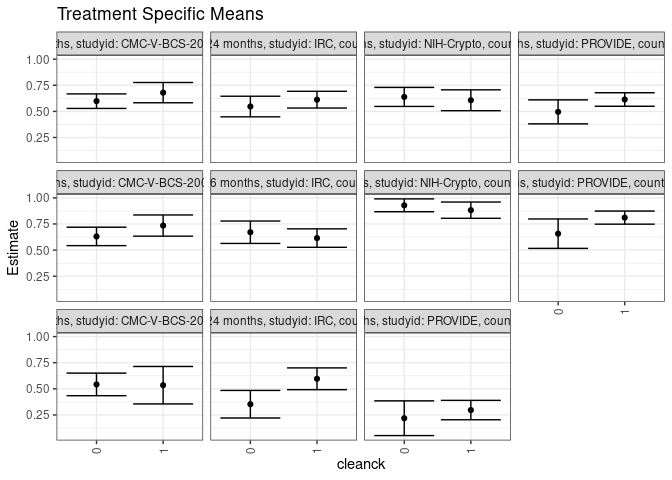

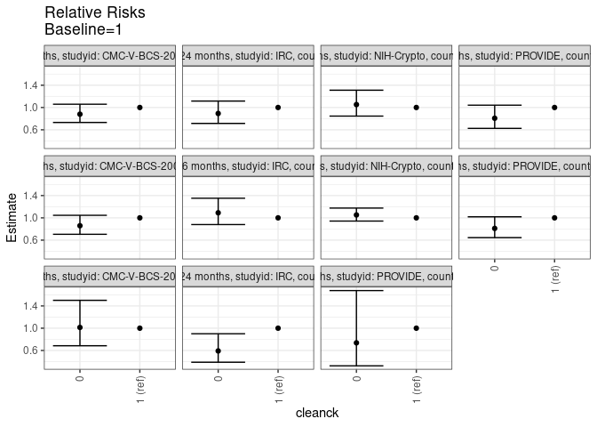

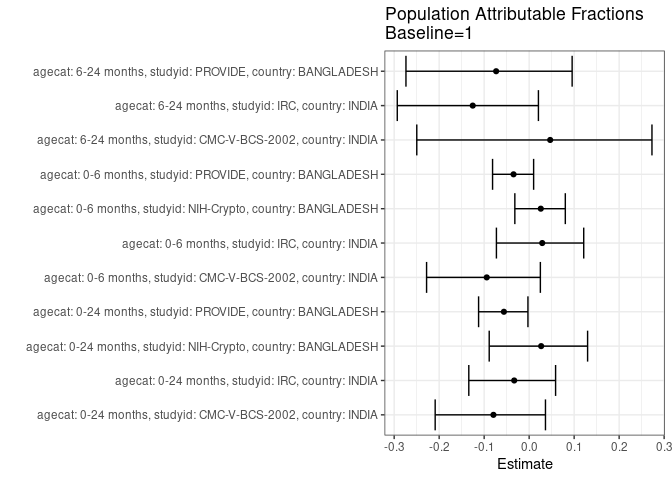

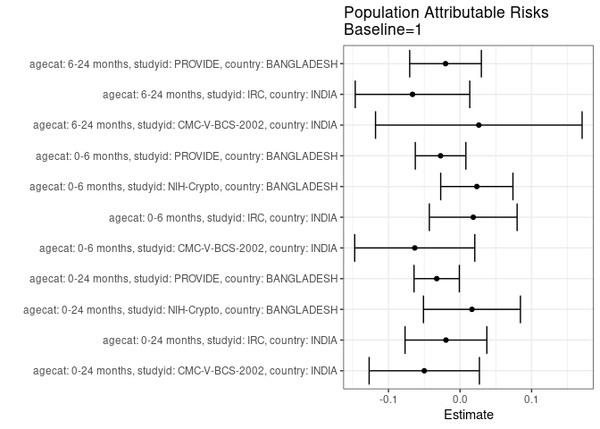

## Results Table

### Parameter: TSM

| agecat | studyid | country | intervention_level | baseline_level | estimate | ci_lower | ci_upper |
| --- | --- | --- | --- | --- | --- | --- | --- |
| 0-24 months | CMC-V-BCS-2002 | INDIA | 1 | NA | 0.6796072 | 0.5826497 | 0.7765648 |
| 0-24 months | CMC-V-BCS-2002 | INDIA | 0 | NA | 0.5978789 | 0.5282133 | 0.6675446 |
| 0-24 months | IRC | INDIA | 1 | NA | 0.6123664 | 0.5323493 | 0.6923835 |
| 0-24 months | IRC | INDIA | 0 | NA | 0.5465984 | 0.4479624 | 0.6452343 |
| 0-24 months | NIH-Crypto | BANGLADESH | 1 | NA | 0.6066264 | 0.5068190 | 0.7064338 |
| 0-24 months | NIH-Crypto | BANGLADESH | 0 | NA | 0.6385322 | 0.5475593 | 0.7295051 |
| 0-24 months | PROVIDE | BANGLADESH | 1 | NA | 0.6137819 | 0.5491042 | 0.6784597 |
| 0-24 months | PROVIDE | BANGLADESH | 0 | NA | 0.4953861 | 0.3805289 | 0.6102434 |
| 0-6 months | CMC-V-BCS-2002 | INDIA | 1 | NA | 0.7349428 | 0.6336252 | 0.8362604 |
| 0-6 months | CMC-V-BCS-2002 | INDIA | 0 | NA | 0.6310302 | 0.5427973 | 0.7192631 |
| 0-6 months | IRC | INDIA | 1 | NA | 0.6151854 | 0.5268579 | 0.7035130 |
| 0-6 months | IRC | INDIA | 0 | NA | 0.6710308 | 0.5638031 | 0.7782586 |
| 0-6 months | NIH-Crypto | BANGLADESH | 1 | NA | 0.8823529 | 0.8043613 | 0.9603446 |
| 0-6 months | NIH-Crypto | BANGLADESH | 0 | NA | 0.9285714 | 0.8671951 | 0.9899477 |
| 0-6 months | PROVIDE | BANGLADESH | 1 | NA | 0.8109731 | 0.7482626 | 0.8736837 |
| 0-6 months | PROVIDE | BANGLADESH | 0 | NA | 0.6572440 | 0.5163698 | 0.7981183 |
| 6-24 months | CMC-V-BCS-2002 | INDIA | 1 | NA | 0.5347410 | 0.3554438 | 0.7140382 |
| 6-24 months | CMC-V-BCS-2002 | INDIA | 0 | NA | 0.5421617 | 0.4340775 | 0.6502459 |
| 6-24 months | IRC | INDIA | 1 | NA | 0.5962278 | 0.4920787 | 0.7003768 |
| 6-24 months | IRC | INDIA | 0 | NA | 0.3527962 | 0.2208190 | 0.4847733 |
| 6-24 months | PROVIDE | BANGLADESH | 1 | NA | 0.2967033 | 0.2039707 | 0.3894359 |
| 6-24 months | PROVIDE | BANGLADESH | 0 | NA | 0.2187500 | 0.0526770 | 0.3848230 |

### Parameter: E(Y)

| agecat | studyid | country | intervention_level | baseline_level | estimate | ci_lower | ci_upper |
| --- | --- | --- | --- | --- | --- | --- | --- |
| 0-24 months | CMC-V-BCS-2002 | INDIA | NA | NA | 0.6296296 | 0.5734927 | 0.6857666 |
| 0-24 months | IRC | INDIA | NA | NA | 0.5926893 | 0.5398764 | 0.6455022 |
| 0-24 months | NIH-Crypto | BANGLADESH | NA | NA | 0.6232558 | 0.5583490 | 0.6881627 |
| 0-24 months | PROVIDE | BANGLADESH | NA | NA | 0.5811688 | 0.5245443 | 0.6377934 |
| 0-6 months | CMC-V-BCS-2002 | INDIA | NA | NA | 0.6716418 | 0.6057305 | 0.7375531 |
| 0-6 months | IRC | INDIA | NA | NA | 0.6336207 | 0.5704020 | 0.6968394 |
| 0-6 months | NIH-Crypto | BANGLADESH | NA | NA | 0.9057971 | 0.8561988 | 0.9553954 |
| 0-6 months | PROVIDE | BANGLADESH | NA | NA | 0.7837838 | 0.7252863 | 0.8422812 |
| 6-24 months | CMC-V-BCS-2002 | INDIA | NA | NA | 0.5609756 | 0.4682842 | 0.6536670 |
| 6-24 months | IRC | INDIA | NA | NA | 0.5298013 | 0.4450066 | 0.6145960 |
| 6-24 months | PROVIDE | BANGLADESH | NA | NA | 0.2764228 | 0.1950773 | 0.3577682 |

### Parameter: RR

| agecat | studyid | country | intervention_level | baseline_level | estimate | ci_lower | ci_upper |
| --- | --- | --- | --- | --- | --- | --- | --- |
| 0-24 months | CMC-V-BCS-2002 | INDIA | 1 | 1 | 1.0000000 | 1.0000000 | 1.000000 |
| 0-24 months | CMC-V-BCS-2002 | INDIA | 0 | 1 | 0.8797419 | 0.7311019 | 1.058602 |
| 0-24 months | IRC | INDIA | 1 | 1 | 1.0000000 | 1.0000000 | 1.000000 |
| 0-24 months | IRC | INDIA | 0 | 1 | 0.8926001 | 0.7141396 | 1.115657 |
| 0-24 months | NIH-Crypto | BANGLADESH | 1 | 1 | 1.0000000 | 1.0000000 | 1.000000 |
| 0-24 months | NIH-Crypto | BANGLADESH | 0 | 1 | 1.0525954 | 0.8455315 | 1.310368 |
| 0-24 months | PROVIDE | BANGLADESH | 1 | 1 | 1.0000000 | 1.0000000 | 1.000000 |
| 0-24 months | PROVIDE | BANGLADESH | 0 | 1 | 0.8071045 | 0.6254896 | 1.041452 |
| 0-6 months | CMC-V-BCS-2002 | INDIA | 1 | 1 | 1.0000000 | 1.0000000 | 1.000000 |
| 0-6 months | CMC-V-BCS-2002 | INDIA | 0 | 1 | 0.8586113 | 0.7049620 | 1.045749 |
| 0-6 months | IRC | INDIA | 1 | 1 | 1.0000000 | 1.0000000 | 1.000000 |
| 0-6 months | IRC | INDIA | 0 | 1 | 1.0907782 | 0.8796261 | 1.352617 |
| 0-6 months | NIH-Crypto | BANGLADESH | 1 | 1 | 1.0000000 | 1.0000000 | 1.000000 |
| 0-6 months | NIH-Crypto | BANGLADESH | 0 | 1 | 1.0523810 | 0.9424090 | 1.175186 |
| 0-6 months | PROVIDE | BANGLADESH | 1 | 1 | 1.0000000 | 1.0000000 | 1.000000 |
| 0-6 months | PROVIDE | BANGLADESH | 0 | 1 | 0.8104387 | 0.6448446 | 1.018557 |
| 6-24 months | CMC-V-BCS-2002 | INDIA | 1 | 1 | 1.0000000 | 1.0000000 | 1.000000 |
| 6-24 months | CMC-V-BCS-2002 | INDIA | 0 | 1 | 1.0138772 | 0.6850215 | 1.500606 |
| 6-24 months | IRC | INDIA | 1 | 1 | 1.0000000 | 1.0000000 | 1.000000 |
| 6-24 months | IRC | INDIA | 0 | 1 | 0.5917137 | 0.3888037 | 0.900519 |
| 6-24 months | PROVIDE | BANGLADESH | 1 | 1 | 1.0000000 | 1.0000000 | 1.000000 |
| 6-24 months | PROVIDE | BANGLADESH | 0 | 1 | 0.7372685 | 0.3243804 | 1.675702 |

### Parameter: PAR

| agecat | studyid | country | intervention_level | baseline_level | estimate | ci_lower | ci_upper |
| --- | --- | --- | --- | --- | --- | --- | --- |
| 0-24 months | CMC-V-BCS-2002 | INDIA | 1 | NA | -0.0499776 | -0.1270148 | 0.0270596 |
| 0-24 months | IRC | INDIA | 1 | NA | -0.0196771 | -0.0768319 | 0.0374776 |
| 0-24 months | NIH-Crypto | BANGLADESH | 1 | NA | 0.0166294 | -0.0511174 | 0.0843763 |
| 0-24 months | PROVIDE | BANGLADESH | 1 | NA | -0.0326131 | -0.0642861 | -0.0009401 |
| 0-6 months | CMC-V-BCS-2002 | INDIA | 1 | NA | -0.0633010 | -0.1471874 | 0.0205854 |
| 0-6 months | IRC | INDIA | 1 | NA | 0.0184353 | -0.0428942 | 0.0797647 |
| 0-6 months | NIH-Crypto | BANGLADESH | 1 | NA | 0.0234442 | -0.0270350 | 0.0739233 |
| 0-6 months | PROVIDE | BANGLADESH | 1 | NA | -0.0271893 | -0.0625214 | 0.0081427 |
| 6-24 months | CMC-V-BCS-2002 | INDIA | 1 | NA | 0.0262346 | -0.1180927 | 0.1705620 |
| 6-24 months | IRC | INDIA | 1 | NA | -0.0664265 | -0.1464535 | 0.0136006 |
| 6-24 months | PROVIDE | BANGLADESH | 1 | NA | -0.0202805 | -0.0703437 | 0.0297826 |

### Parameter: PAF

| agecat | studyid | country | intervention_level | baseline_level | estimate | ci_lower | ci_upper |
| --- | --- | --- | --- | --- | --- | --- | --- |
| 0-24 months | CMC-V-BCS-2002 | INDIA | 1 | NA | -0.0793762 | -0.2088745 | 0.0362499 |
| 0-24 months | IRC | INDIA | 1 | NA | -0.0331997 | -0.1341393 | 0.0587562 |
| 0-24 months | NIH-Crypto | BANGLADESH | 1 | NA | 0.0266815 | -0.0887672 | 0.1298885 |
| 0-24 months | PROVIDE | BANGLADESH | 1 | NA | -0.0561164 | -0.1123760 | -0.0027022 |
| 0-6 months | CMC-V-BCS-2002 | INDIA | 1 | NA | -0.0942482 | -0.2279765 | 0.0249169 |
| 0-6 months | IRC | INDIA | 1 | NA | 0.0290951 | -0.0727523 | 0.1212731 |
| 0-6 months | NIH-Crypto | BANGLADESH | 1 | NA | 0.0258824 | -0.0318118 | 0.0803505 |
| 0-6 months | PROVIDE | BANGLADESH | 1 | NA | -0.0346899 | -0.0813223 | 0.0099315 |
| 6-24 months | CMC-V-BCS-2002 | INDIA | 1 | NA | 0.0467660 | -0.2497610 | 0.2729370 |
| 6-24 months | IRC | INDIA | 1 | NA | -0.1253799 | -0.2931156 | 0.0205980 |
| 6-24 months | PROVIDE | BANGLADESH | 1 | NA | -0.0733678 | -0.2738040 | 0.0955293 |